# Data Collection and Analysis Pre-registration for Novel Generics on People’s Habits

Xiuyuan Zhang and Dan Yurovsky

01/10/2019

This script contains codes that we plan to use for our next collection of data on participants’ prevalence estimation of people’s habits when they hear these habits in a generic statements about people from novel countries.

We plan to collect data from 400 participants.

### Load libraries

```r
library(tidyverse)
library(lubridate)
library(lme4)
library(DT)
library(ggpirate)
library(gridExtra)
library(knitr)
library(tidyboot)
library(Matrix)
library(effsize)
library(pwr)
library(compute.es)
library(janitor)
library(tidyboot)
theme_set(theme_classic(base_size = 14))
```

### Read in anonymized data

We read in anonymized data (see `010919_preregistration_process_raw_data.R` for criterion applied to drop certain columns for privacy reasons)

```r
data_new <- read_csv("data/01102019_people_novel_habit_anonymized_data.csv")
data_old <- read_csv("../baseline-people-habits/data/10312018_people_habit_anonymized_data.csv")
```

The total number of participants we get from this new collection of data is 398.

### Applying filtering Criterion

#### Pass attention check

We set an attention check question at the end of our survey, asking participants to select four questions out of all questions they’ve seen previously in our survey. If participants fail the attention check(don’t select all four correct questions), we will drop them from our sample.

#### Gender & Age filtering

Below, we first show that, in a previous collection of data, the distribuition of participants after 60 years old becomes sparse. The 94 percentile in our previous data samples has been 60 years old. We will then apply a cut-off of 60 years old for this new data and only include data for participants with age younger than 60 years old.

Based on previous data, we do not have many turkers select “Other/Non-comforming” for our question on gender information(3 out of 773). For this upcoming study, we will filter out Other/Non-conforming from our sample.

```r
# filter by condition: passing attention check
old_attnCheckAnswers <- c('drink coffee','cook at home', 'go to the gym', 'drive to work')

old_qualtrics_filtered <- data_old %>%
    rowwise() %>%
  mutate(attention_check = (strsplit(attention_check, ','))) %>%
  mutate(attnTrue = sum(attention_check %in% old_attnCheckAnswers),
         attnFalse= sum(!attention_check %in% old_attnCheckAnswers))%>%
  filter(attnFalse==0)

# showing the basic count for demographic information
old_qualtrics_filtered %>%
  group_by(gender) %>%
  summarise(n = n())%>%
  kable()
```

| gender | n |
| --- | --- |
| Female | 393 |
| Male | 377 |
| Other/Non-conforming | 3 |

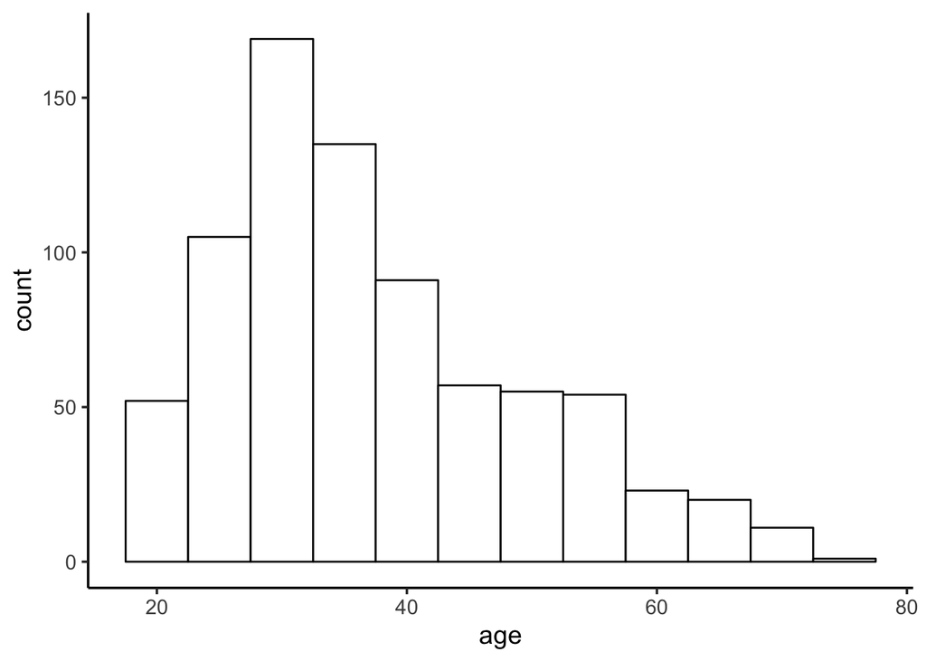

```r
old_qualtrics_filtered %>%
  ggplot(aes(x = age)) +
  geom_histogram(binwidth = 5, fill = "white", color = "black")
```

```r
old_tidy_data <- old_qualtrics_filtered %>%
  filter(gender != "Other/Non-conforming") %>%
  mutate(gender = factor(gender, levels = c("Female", "Male"), labels = c("female", "male")))

old_tidy_data %>%
  group_by(gender) %>%
  summarise(n = n()) %>%
  kable()
```

| gender | n |
| --- | --- |
| female | 393 |
| male | 377 |

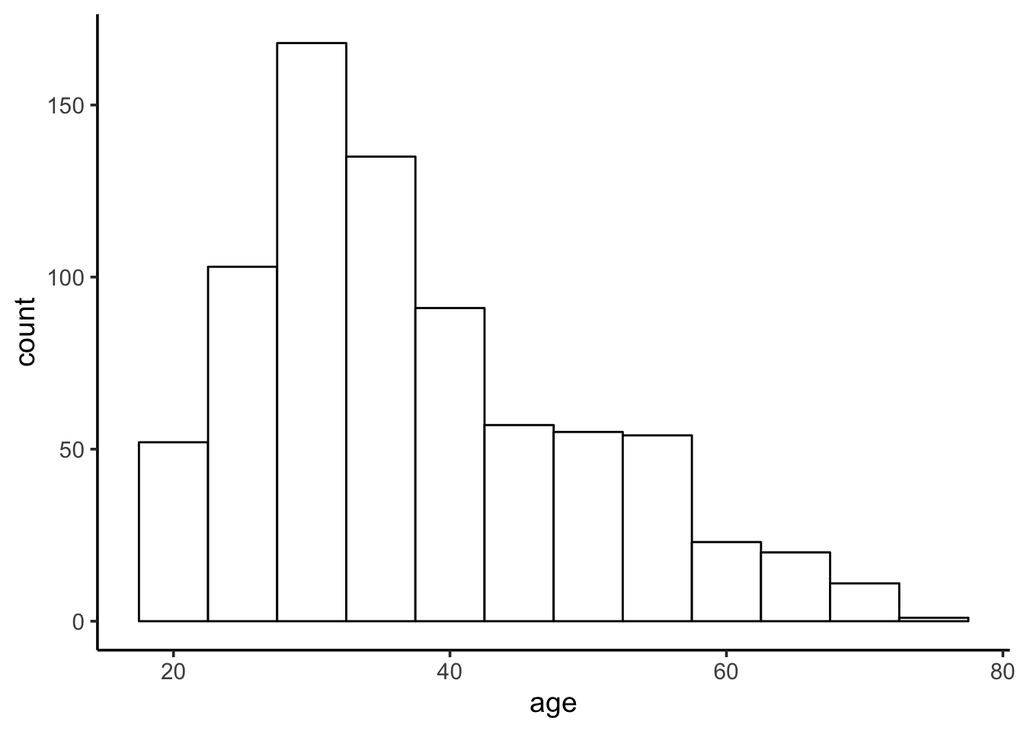

```r
old_tidy_data %>%
  ggplot(aes(x = age)) +
  geom_histogram(binwidth = 5, fill = "white", color = "black")
```

```r
old_filtered_data <- old_tidy_data %>%
  filter(age < 60) %>%
  mutate(age_bin = if_else(age > median(old_tidy_data$age), "older", "younger"),
         politics_bin = if_else(politics_1 > median(old_tidy_data$politics_1),
                                "conservative", "liberal"))
```

```r
new_attnCheckAnswers <- c('like big cities','cook at home', 'go to the gym', 'consume dairy products')

new_qualtrics_filtered <- data_new %>%
    rowwise() %>%
  mutate(attention_check = (strsplit(attention_check, ','))) %>%
  mutate(attnTrue = sum(attention_check %in% new_attnCheckAnswers),
         attnFalse= sum(!attention_check %in% new_attnCheckAnswers))%>%
  filter(attnTrue ==4 & attnFalse==0)
```

Filter peole who passed the attention check, result: n = 335 (out of 398 )

```r
new_tidy_data <- new_qualtrics_filtered %>%
  filter(gender != "Other/Non-conforming") %>%
  mutate(gender = factor(gender, levels = c("Female", "Male"), labels = c("female", "male")))

new_tidy_data %>%
  group_by(gender) %>%
  summarise(n = n()) %>%
  kable()
```

| gender | n |
| --- | --- |
| female | 174 |
| male | 159 |

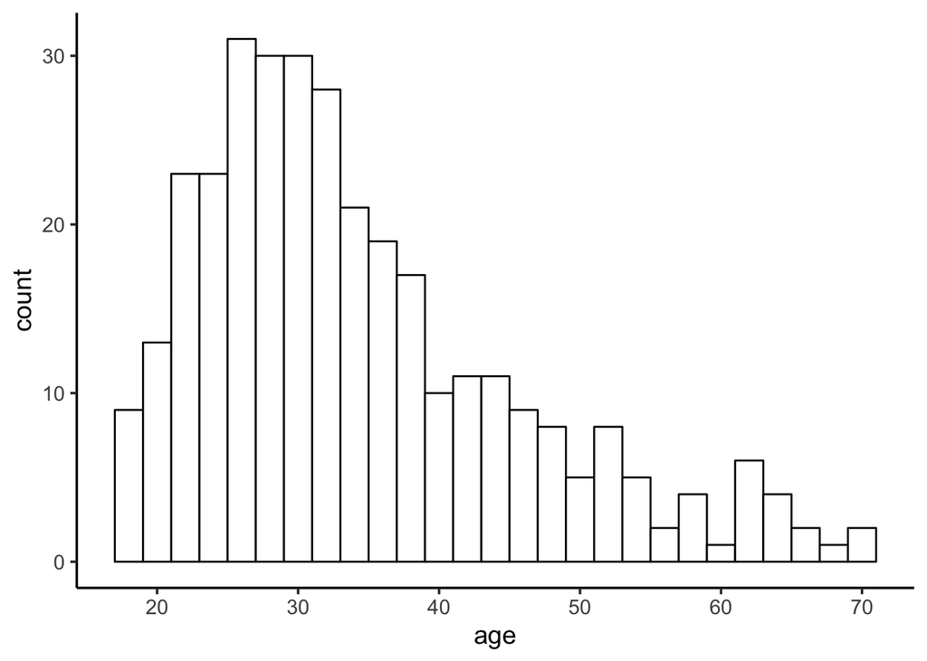

```r
new_tidy_data %>%
  ggplot(aes(x = age)) +
  geom_histogram(binwidth = 2, fill = "white", color = "black")
```

```r
new_filtered_data <- new_tidy_data %>%
  filter(age < 60) %>%
  mutate(age_bin = if_else(age > median(old_tidy_data$age), "older", "younger"),
         politics_bin = if_else(politics_1 > median(old_tidy_data$politics_1),
                                "conservative", "liberal"))

new_filtered_data %>%
  group_by(gender, age_bin, politics_bin) %>%
  summarise(n = n(), age = mean(age), politics = mean(politics_1)) %>%
  kable()
```

[output not shown]

By filtering to participants younger than 60 years old, we lost 16 people

### Exploratory Data Analysis

#### organize data in long format

```r
old_long_data <- old_filtered_data %>%
  select(big_cities_1, computer_preference_1, cook_at_home_1,own_homes_1, dairy_products_1, go_to_gym_1, gender, age_bin, politics_bin, id) %>%
  gather(question, response, big_cities_1, computer_preference_1, cook_at_home_1,own_homes_1, dairy_products_1, go_to_gym_1)

new_long_data <- new_filtered_data %>%
  select(big_cities_1:go_to_gym_1,
         gender, age_bin, politics_bin, id)%>%
  gather(question, response, big_cities_1:go_to_gym_1)
```

#### analyze the correlation between previous data and incoming data

```r
new_data <- new_long_data %>%
  group_by(id) %>%
  mutate(response = scale(response)) %>%
  group_by(gender, age_bin, politics_bin, question) %>%
  summarise(mean = mean(response, na.rm = T)) %>%
  mutate(data = "new")

old_data <- old_long_data %>%
  group_by(id) %>%
  mutate(response = scale(response)) %>%
  group_by(gender, age_bin, politics_bin, question) %>%
  summarise(mean = mean(response)) %>%
  mutate(data = "old")

all_data <- bind_rows(new_data, old_data) %>%
  group_by(question) %>%
  spread(data, mean) %>%
  summarise(cor = cor(new, old, use = "complete"))

t.test(all_data$cor)
```

```
##
##  One Sample t-test
##
## data:  all_data$cor
## t = 5.5807, df = 5, p-value = 0.002547
## alternative hypothesis: true mean is not equal to 0
## 95 percent confidence interval:
##  0.2457980 0.6656069
## sample estimates:
## mean of x
## 0.4557025
```